# *hespresso*: 3. Simulation Evaluation

Jianqiang Sun

Research Center for Agricultural Information Technology, National Agriculture and Food Research Organization, Japan

Updated: 2025-07-06 Compiled: 2025-07-25.

#### Abstract

Simulation studies offer a powerful approach for evaluating method performance under controlled conditions. The *hespresso* package includes a suite of functions to generate artificial datasets that simulate read counts from allopolyploid species. These functions enable comprehensive assessment of HOBIT and related methods across a range of experimental scenarios.

#### Package

hespresso 0.99.1

# 1 Simulating Allotetraploid Data

The hespresso package provides functions to simulate artificial read counts for allotetraploid and allohexaploid species. By default, the simulation generates read counts for an allotetraploid with 10,000 homeologs across two conditions, each with three biological replicates. The mean and dispersion parameters are estimated from real RNA-Seq data from an allotetraploid *Cardamine flexuosa* dataset (Akiyama et al. 2021).

To generate a simulated dataset with default options, run as follows.

```r
x <- sim_homeolog_counts()
x
```

```
## # 2 subgenomes (A, B)
## # 10000 homeologs
## ---------------------
## Experiment Design:
##     group replicate
## 1 group_1         1
## 2 group_1         2
## 3 group_1         3
## 4 group_2         1
## 5 group_2         2
## 6 group_2         3
## ---------------------
## > subgenome: A
##        group_1__1 group_1__2 group_1__3 group_2__1 group_2__2 group_2__3
## gene_1         27         22         16         14         14         22
## gene_2        278          4         12         87        113         93
## gene_3        614        316        433        437        228        631
## gene_4        360        341        311        359        237        411
## gene_5        138         42        214        150        189        165
## gene_6       1028       1063       1171        383        385        342
## +++++++++++++++++++++
## > subgenome: B
##        group_1__1 group_1__2 group_1__3 group_2__1 group_2__2 group_2__3
## gene_1          9         21         11         21         19         21
## gene_2        124        107        123        218        187        200
## gene_3        162        149        206        180        235        259
## gene_4        373        329        384        353        269        374
## gene_5         63         45         69         75         49         43
## gene_6        101         93        102         67         98         83
## ---------------------
```

Options can be flexibly customized by users. For example, to simulate data with 1,000 homeologs and 5 replicates per condition, run as follows.

```r
x <- sim_homeolog_counts(n_gene = 1000, n_replicates = c(5, 5))
x
```

```
## # 2 subgenomes (A, B)
## # 1000 homeologs
## ---------------------
## Experiment Design:
##      group replicate
## 1  group_1         1
## 2  group_1         2
## 3  group_1         3
## 4  group_1         4
## 5  group_1         5
## 6  group_2         1
## 7  group_2         2
## 8  group_2         3
## 9  group_2         4
## 10 group_2         5
## ---------------------
## > subgenome: A
##        group_1__1 group_1__2 group_1__3 group_1__4 group_1__5 group_2__1
## gene_1         59         58         58         51         47         70
## gene_2          8          2          5         36         13          6
## gene_3          4          4          4          4          9          0
## gene_4         27         34         34         28         18          8
## gene_5         52         43         32         54         37         31
## gene_6       1273       1749       1696       2733       1867       1506
##        group_2__2 group_2__3 group_2__4 group_2__5
## gene_1         43         71         53         45
## gene_2          9          6          7          6
## gene_3          0          1          8          0
## gene_4          6         10         18         15
## gene_5         10          5         22         10
## gene_6       1748       1757       2009       1948
## +++++++++++++++++++++
## > subgenome: B
##        group_1__1 group_1__2 group_1__3 group_1__4 group_1__5 group_2__1
## gene_1         12          3         36          0          7         23
## gene_2          6          3          5          2          7          0
## gene_3          6          7          9         10          4          8
## gene_4         33         12          2          0          1          7
## gene_5        202        136        178        156        189        188
## gene_6        793        842        918        800        937        989
##        group_2__2 group_2__3 group_2__4 group_2__5
## gene_1         21         19         26         13
## gene_2          0          0          0          0
## gene_3          8         12          8          8
## gene_4          5         11          2          8
## gene_5        167        163        167        153
## gene_6       1112        845        945        992
## ---------------------
```

Simulated read counts are generated from a **negative binomial** (**NB**) distribution. The mean and dispersion values used for each homeolog are stored in the object returned by `sim_homeolog_counts()`. The `get_sim_params()` function can be used to retrieve these parameters. For example, to get means used for sampling read counts, run as follows.

```r
param_mu <- get_sim_params(x, "mu")
```

The output is a list of data.frame objects, with each element corresponding to a condition group. Each data.frame contains the true mean expression values used for sampling, where the columns represent individual subgenomes. These ground-truth mean values can be used to calculate the true **homeolog expression ratios** (**HERs**) for each condition. Based on these HERs, users can set thresholds to define homeologs that shift HERs significantly, referred to as **ratio-shifted homeologs** (**RSHs**), between conditions.

```r
names(param_mu)
```

```
## [1] "group_1" "group_2"
```

```r
head(param_mu[["group_1"]])
```

```
##                  A          B
## gene_1   56.491374  17.328355
## gene_2    8.006597   4.818938
## gene_3    5.944184   6.766986
## gene_4   28.174125   7.362780
## gene_5   44.853340 166.388422
## gene_6 1902.944015 899.045310
```

Alternatively, users can use the `def_sigShift()` function to automatically define RSHs without manually calculating summary statistics. For example, to identify RSHs as those with a maximum absolute HER difference (`Dmax`) greater than 0.2 or a maximum odds ratio (`ORmax`) exceeding 2.0, use the following command.

```r
x <- sim_homeolog_counts()

is_sig <- def_sigShift(x, Dmax = 0.2, ORmax = 2, operator = "OR")
table(is_sig)
```

```
## is_sig
## FALSE  TRUE
##  9260   740
```

The output indicates that there are 740 RSHs defined with the specific thresholds.

To visualize the distribution of HERs across conditions, use the `plot_HER_distr()` function. This function returns a list of histograms, one for each group, showing HER distributions. By default, HERs of the first subgenome (`base = 1`) are computed.

```r
x <- sim_homeolog_counts()
distr_plots <- plot_HER_distr(x)
```

Since the simulated dataset contains two groups, the `plot_HER_distr()` function returns two histograms.

```r
names(distr_plots)
```

```
## [1] "group_1" "group_2"
```

To show the HER distribution for each group, run as follows.

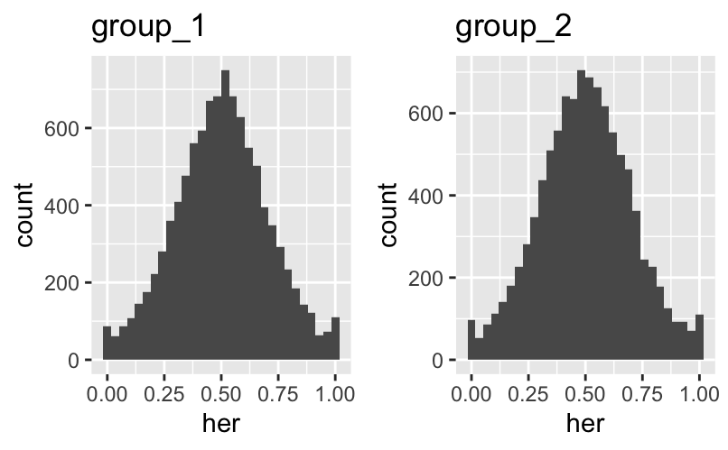

Figure 1: Distribution of Homeolog Expression Ratios  
Histograms display the distributions of homeolog expression ratios under two simulated groups.

```r
library(ggplot2)
library(gridExtra)

grid.arrange(distr_plots[["group_1"]] + ggtitle("group_1"),
             distr_plots[["group_2"]] + ggtitle("group_2"),
             ncol = 2)
```

To compare HER changes between groups, user can use the `plot_HER()` function. By default, it plots HERs for the first subgenome between two groups using a scatter plot.

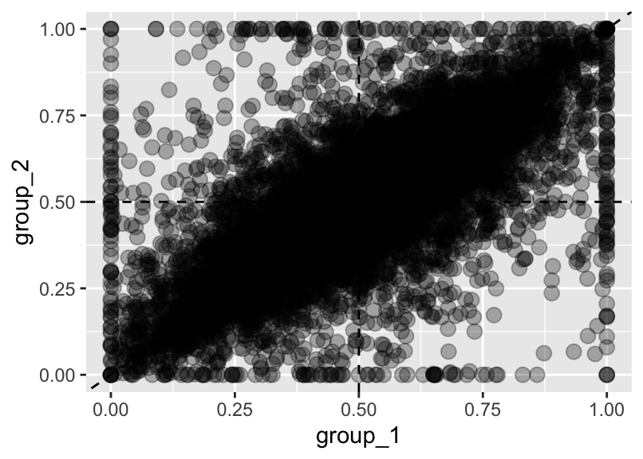

Figure 2: Changes in Homeolog Expression Ratios Between Two Groups  
Each point represents the homeolog expression ratio in group 1 (x-axis) and group 2 (y-axis).

```r
plot_HER(x, alpha = 0.3)
```

If the dataset was generated using `sim_homeolog_counts()`, user can incorporate the `def_sigShift()` function to highlight ground-true RSHs in the plot.

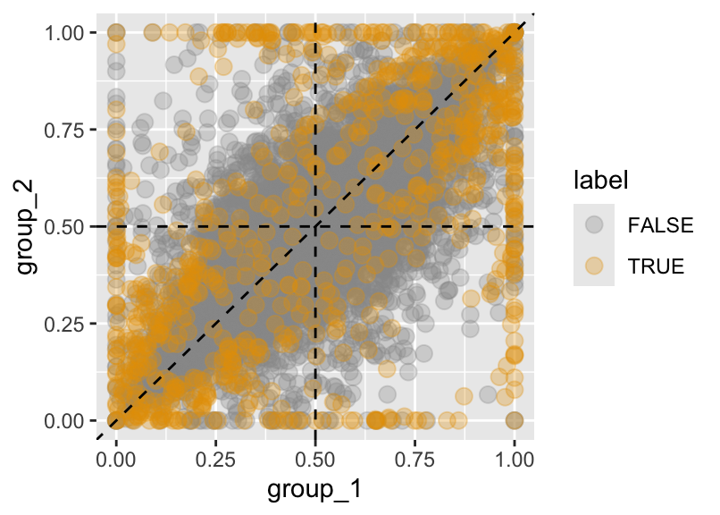

Figure 3: Changes in Homeolog Expression Ratios Between Two Groups  
Orange points indicate homeologs with significant shifts in expression ratios between the two groups, whereas gray points represent homeologs without significant changes.

```r
is_sig <- def_sigShift(x, Dmax = 0.2, ORmax = 2.0)
plot_HER(x, label = is_sig, alpha = 0.3)
```

# 2 Simulating Allohexaploid Data

To simulate read counts for an allohexaploid with three subgenomes, set `n_subgenomes = 3`. In this case, the mean and dispersion parameters are derived from real RNA-Seq data from allohexaploid wheat (Yang et al. 2021).

```r
x <- sim_homeolog_counts(n_subgenomes = 3)
```

The simulation parameters can be retrieved using the `get_sim_params()` function and the ground-truth RSHs can be defined with the `def_sigShift()` function, as like example showing for allotetraploid data.

For exmaple, using `def_sigShift()` function can define ground-truth RSHs, homeologs with large changes satisfied the given thresholds in any subgenome.

```r
is_sig <- def_sigShift(x, Dmax = 0.2, ORmax = 2, operator = "OR")
table(is_sig)
```

```
## is_sig
## FALSE  TRUE
##  9251   749
```

Alternatively, to define RSHs specific to a single subgenome, for example, only the first subgenome, set the `base` argument accordingly as follows.

```r
x <- sim_homeolog_counts(n_subgenomes = 3)

is_sig <- def_sigShift(x, base = 1, Dmax = 0.2, ORmax = 2, operator = "OR")
table(is_sig)
```

```
## is_sig
## FALSE  TRUE
##  9662   338
```

Visualization for allohexaploid data, comprising three subgenomes, works similarly.

```r
x <- sim_homeolog_counts(n_subgenomes = 3)
distr_plots_1 <- plot_HER_distr(x)
names(distr_plots_1)
```

```
## [1] "group_1" "group_2"
```

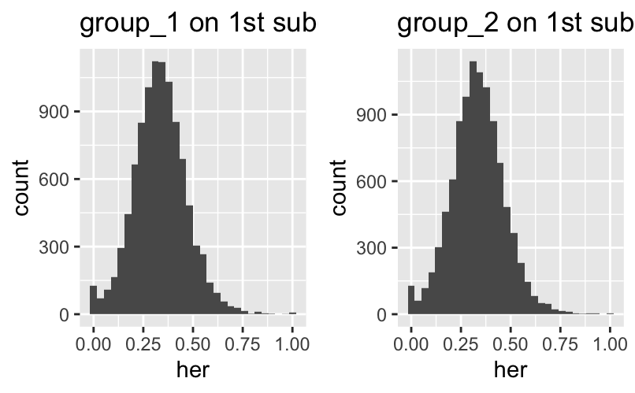

Figure 4: Distribution of Homeolog Expression Ratios for the First Subgenome  
Histograms illustrate the distributions of homeolog expression ratios for the first subgenome in a simulated allohexaploid dataset across two experimental groups.

```r
library(ggplot2)
library(gridExtra)
grid.arrange(distr_plots_1[["group_1"]] + ggtitle("group_1 on 1st subgenome"),
             distr_plots_1[["group_2"]] + ggtitle("group_2 on 1st subgenome"),
             ncol = 2)
```

User can specify which subgenome to use for HER calculations with the `base` argument. For example, to visualize HERs for the second subgenome.

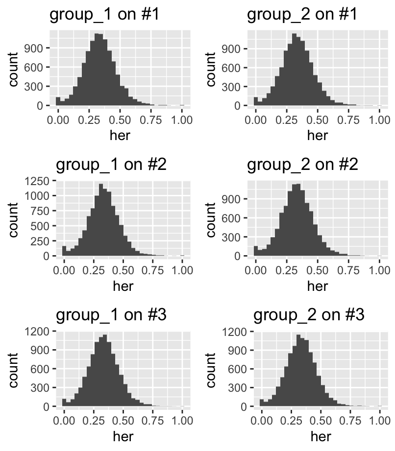

Figure 5: Distribution of Homeolog Expression Ratios Across All Subgenomes  
Histograms show the distributions of homeolog expression ratios for the first, second, and third subgenomes in a simulated allohexaploid dataset across two groups.

```r
distr_plots_2 <- plot_HER_distr(x, base = 2)
distr_plots_3 <- plot_HER_distr(x, base = 3)

grid.arrange(distr_plots_1[["group_1"]] + ggtitle("group_1 on #1"), distr_plots_1[["group_2"]] + ggtitle("group_2 on #1"),
             distr_plots_2[["group_1"]] + ggtitle("group_1 on #2"), distr_plots_2[["group_2"]] + ggtitle("group_2 on #2"),
             distr_plots_3[["group_1"]] + ggtitle("group_1 on #3"), distr_plots_3[["group_2"]] + ggtitle("group_2 on #3"),
             ncol = 2)
```

The `plot_HER()` function also works for allohexaploids. By default, HERs are computed from the first subgenome.

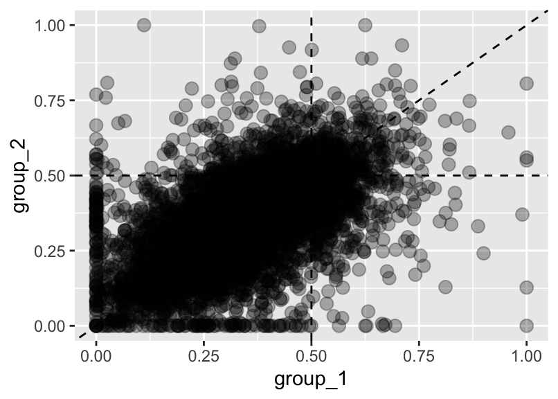

Figure 6: Changes in Homeolog Expression Ratios of the First Subgenome Between Two Groups  
Each point represents the homeolog expression ratio of the first subgenome in two groups.

```r
plot_HER(x, alpha = 0.3)
```

To specify which subgenome to use for HER calculations, user can use the `base` argument. The following example visualizes HERs of the second subgenome between two groups.

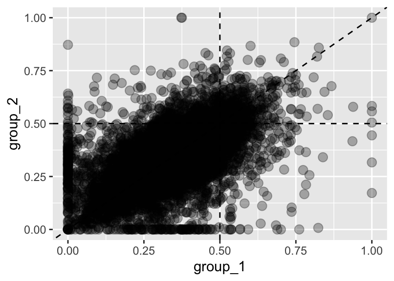

Figure 7: Changes in Homeolog Expression Ratios of the Second Subgenome Between Two Groups  
Each point represents the homeolog expression ratio of the second subgenome in two groups.

```r
plot_HER(x, base = 2, alpha = 0.3)
```

In addition, with simulated data, user can incorporate the `def_sigShift()` function to obtain the ground-truth RSHs and highlight them in the scatter plot. The following example visualizes HERs of the first subgenome between two groups and highlights homeologs that satisfy the RSH thresholds in any subgenome. Since the RSHs are defined across all subgenomes while the plot only shows the first subgenome, homeologs with minimal changes in the first subgenome may still appear highlighted.

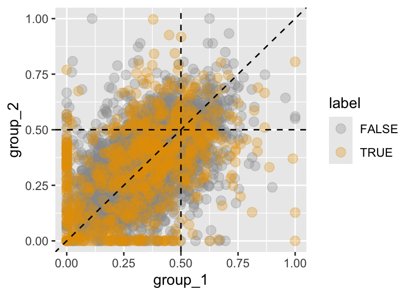

Figure 8: Changes in Homeolog Expression Ratios of the First Subgenome Between Two Groups  
Orange points represent homeologs with significant changes in expression ratios between the two groups for any subgenome, while gray points indicate homeologs without significant changes.

```r
is_sig <- def_sigShift(x, base = 0, Dmax = 0.2, ORmax = 2)
plot_HER(x, label = is_sig, alpha = 0.3)
```

Alternatively, to highlight only those homeologs that meet the RSH threshold specifically in the first subgenome, use as the follows.

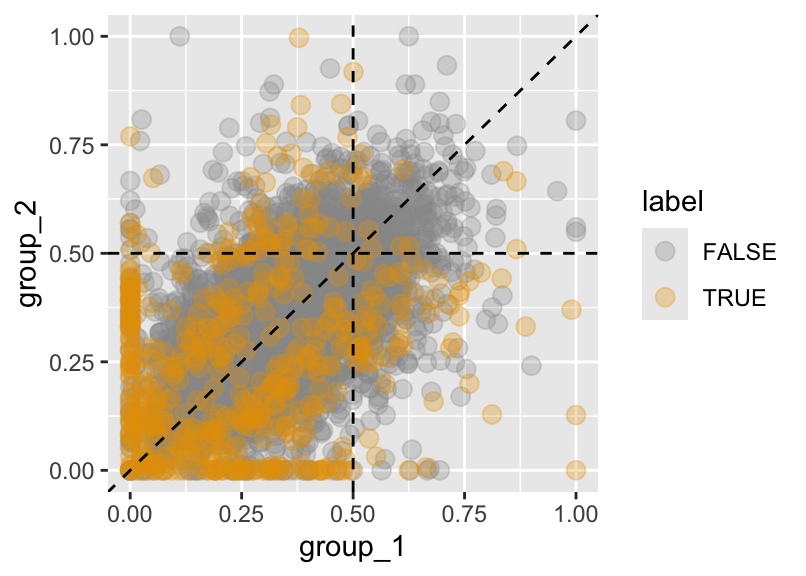

Figure 9: Changes in Homeolog Expression Ratios of the First Subgenome Between Two Groups  
Orange points represent homeologs with significant changes in expression ratios of the first subgenome between the two groups, while gray points indicate homeologs without significant changes.

```r
is_sig_b1 <- def_sigShift(x, base = 1, Dmax = 0.2, ORmax = 1.8)
plot_HER(x, base = 1, label = is_sig_b1, alpha = 0.3)
```

# 3 Simulating from a Custom Expression Seed

Instead of using the default datasets based on *C. flexuosa* or wheat, users can supply their own expression matrix to calculate the mean and dispersion parameters for simulation. The matrix should be formatted with genes as rows and samples (biological replicates) as columns. Each cell should contain a normalized read count.

Below is an example showing how to load a custom matrix and use it as a template for simulation.

```r
expmx <- read.table(system.file(package = "hespresso", "extdata", "seed_matrix.C_flexuosa.tsv.gz"))
head(expmx)
```

```
##    V1  V2  V3
## 1  90  50   6
## 2   8  13   6
## 3 319 351 472
## 4 683 671 535
## 5 258 162 160
## 6  69  74  81
```

```r
x <- sim_homeolog_counts(seed_expmx = expmx)
x
```

```
## # 2 subgenomes (A, B)
## # 10000 homeologs
## ---------------------
## Experiment Design:
##     group replicate
## 1 group_1         1
## 2 group_1         2
## 3 group_1         3
## 4 group_2         1
## 5 group_2         2
## 6 group_2         3
## ---------------------
## > subgenome: A
##        group_1__1 group_1__2 group_1__3 group_2__1 group_2__2 group_2__3
## gene_1        516        460        492          0          0          0
## gene_2          0          0          0          0          0          1
## gene_3        453        545        391        530        471        520
## gene_4        101        210        189         76         78        100
## gene_5        194        184        206        147        171        224
## gene_6         30         50         30         31         32         25
## +++++++++++++++++++++
## > subgenome: B
##        group_1__1 group_1__2 group_1__3 group_2__1 group_2__2 group_2__3
## gene_1        195        237        235        204        247        152
## gene_2          0          0          0          1          4          2
## gene_3        891       1151       1406       1206        959        814
## gene_4        112        132        118        183        188        115
## gene_5        193        278        227        268        237        281
## gene_6         60         36         50         64         67         61
## ---------------------
```

This function allows users to evaluate HOBIT performance on data representative of their own study system.

# 4 Performance Evaluation

By combining the `sim_homeolog_counts()` and `def_sigShift()` functions, users can evaluate the performance of HOBIT using standard metrics such as precision, recall, F1 score, and area under the ROC curve (AUC).

For a reliable evaluation of HOBIT, we recommend simulating a large number of homeologs to ensure the dataset includes a sufficient number of RSHs for robust validation. However, to reduce computation time in this example, we simulate data for only 100 homeologs for performance evaluation.

```r
x <- sim_homeolog_counts(n_genes = 100)
x_output <- hobit(x)
```

Next, we identify predicted RSHs using an FDR threshold of 0.05. We then calculate precision, recall, and the F1 score by comparing the predicted RSHs against the ground-truth RSHs, which are defined using the `def_sigShift()` function. To compute the AUC, we use the *p*-values from the `hobit()` output and input them into the `auc()` and `roc()` functions provided by the pROC package.

```r
library(pROC)

pred_sig <- (x_output$qvalue < 0.05)
true_sig <- def_sigShift(x, Dmax = 0.2, ORmax = 2, operator = "OR")

tp <- sum(pred_sig & true_sig)
tn <- sum(!pred_sig & !true_sig)
fp <- sum(pred_sig & !true_sig)
fn <- sum(!pred_sig & true_sig)

precision <- tp / (tp + fp)
recall <- tp / (tp + fn)
f1 <- 2 * precision * recall / (precision + recall)
auc <- auc(roc(true_sig, 1 - x_output$pvalue, levels = c(FALSE, TRUE), direction = "<"))

print(c(precision = precision, recall = recall, f1 = f1, auc = auc))
```

```
## precision    recall        f1       auc
## 0.5000000 0.2307692 0.3157895 0.7740937
```

# References

Akiyama, Reiko, Jianqiang Sun, Masaomi Hatakeyama, Heidi E. L. Lischer, Roman V. Briskine, Angela Hay, Xiangchao Gan, et al. 2021. “Fine-Scale Empirical Data on Niche Divergence and Homeolog Expression Patterns in an Allopolyploid and Its Diploid Progenitor Species.” *New Phytologist* 229(6): 3587–3601. https://doi.org/10.1111/nph.17101.

Yang, Yuxin, Xueying Zhang, Lifen Wu, Lichao Zhang, Guoxiang Liu, Chuan Xia, Xu Liu, and Xiuying Kong. 2021. “Transcriptome Profiling of Developing Leaf and Shoot Apices to Reveal the Molecular Mechanism and Co-Expression Genes Responsible for the Wheat Heading Date.” *BMC Genomics* 22(1): 468. https://doi.org/10.1186/s12864-021-07797-7.